# Overlapping: facciamo chiarezza

Massimiliano Pastore

```
2025-09-08
```

# La Skew-Normal

La Skew-Normal si definisce nel seguente modo: dati $\xi \in \mathbb{R}$, $\omega \in \mathbb{R}^{+}$ e $\alpha \in \mathbb{R}$, allora per $y \in \mathbb{R}$ si ha
$$\begin{eqnarray}
\mathcal{SN}(y|\xi, \omega, \alpha) = \frac{1}{\omega \sqrt{2\pi}} exp \left[ -\frac{1}{2} \left( \frac{y-\xi}{\omega} \right)^2 \right] \left[ 1+ \text{erf}\left( \alpha \left( \frac{y-\xi}{\omega\sqrt{2}}\right) \right) \right]
\end{eqnarray}$$
in cui
$$\text{erf}(z) = \frac{2}{\sqrt{\pi}} \int_{0}^{z} e^{-t^2} dt$$
è l’*error function*. Quando $\xi=0$, $\omega = 1$ e $\alpha = 0$ la distribuzione si riduce alla normale standard.

$\xi$ is the location parameter, $\omega$ is the scale parameter and $\alpha$ is related to the skewness of the distribution. Therefore, this distribution is suitable to generate data modelling both the distance between means (the effect size), symmetry and variance.

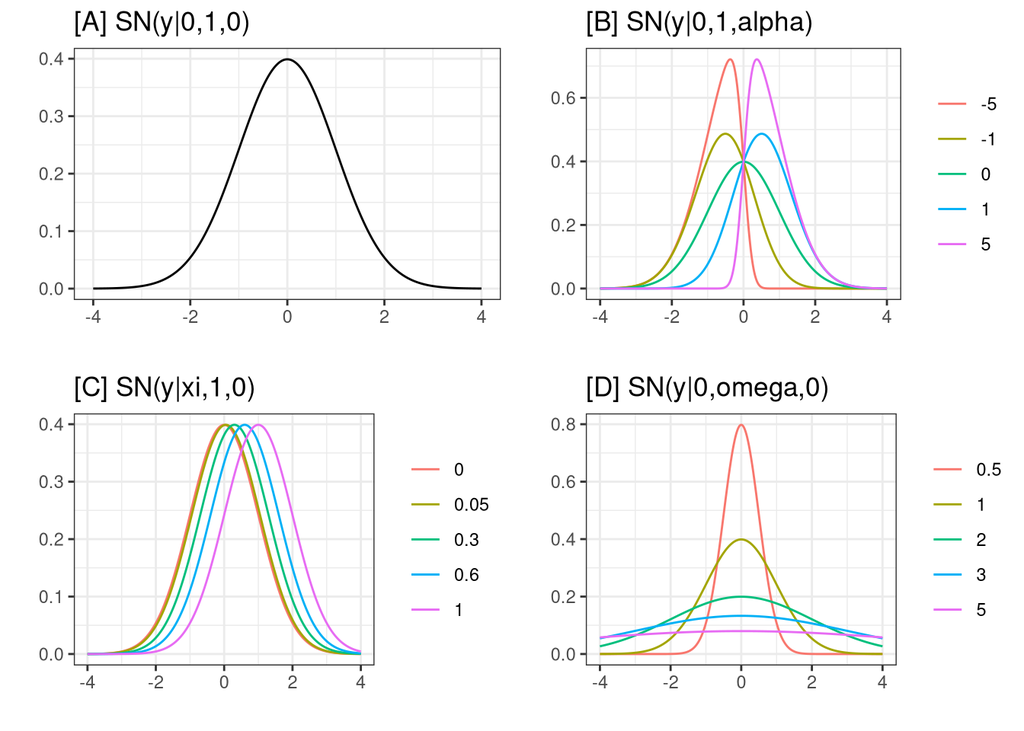

Mean and variance of the Skew-Normal are respectively:
$$\begin{eqnarray}\label{eq:musigmaSN}
\begin{array}{l}
\mu = \xi + \omega \gamma \sqrt{2/\pi} \\
\sigma^2 = \omega^2 [1- (2\gamma^2)/\pi]
\end{array}
\end{eqnarray}$$
in which $\gamma = \alpha / \sqrt{1 + \alpha^2}$. Based on the distribution equations we can determine the values to assign to the parameters $\xi$ e $\omega$ in function of $\mu$ and $\sigma$ with the equations:

$$\begin{eqnarray}\label{eq:xiomegaSN}
\begin{array}{l}
\xi = \mu - \omega \gamma \sqrt{2/\pi} \\
\omega = \sqrt{\sigma^2/ [1- (2\gamma^2)/\pi]}
\end{array}
\end{eqnarray}$$

### Funzioni per la Skew-Normal

Per calcolare $\mu$ e $\sigma$ della SN a partire dai suoi parametri usiamo la funzione:

```r
snpar <- function(xi=0,omega=1,alpha=0) {
  delta <- alpha/sqrt(1+alpha^2)
  mu <- xi + omega * delta * sqrt( 2/pi )
  sigma2 <- omega^2 * ( 1 - (2*delta^2)/pi )
  return(list(mu = mu, sigma = sqrt(sigma2)))
}
```

Per l’inversa, ovvero calcolare $\xi$, $\omega$ e $\alpha$ partendo da $\mu$ e $\sigma$ usiamo la funzione:

```r
sninvpar <- function( mu=0, sigma=1, xi=NULL, omega=NULL, alpha=0 ) {
  if (is.null(omega)) {
    delta <- alpha/sqrt(1+alpha^2)
    omega2 <- sigma^2 / ( 1 - (2*delta^2) / pi )
    omega <- sqrt( omega2 )
  }
  if (is.null(xi)) {
    delta <- alpha/sqrt(1+alpha^2)
    xi <- mu - omega * delta * sqrt( 2/pi )
  }
  return( list( xi = xi, omega = omega, alpha = alpha ) )
}
```

Si noti che inserendo solo $\mu$ e $\sigma$, con il default $\alpha$ = 0, i valori di $\xi$ e $\omega$ saranno identici.

**Qualche esempio**

```r
snpar( 0, 1, 0 )
```

```
$mu
[1] 0

$sigma
[1] 1
```

```r
sninvpar( 0, 1 )
```

```
$xi
[1] 0

$omega
[1] 1

$alpha
[1] 0
```

```r
snpar( 1, 3, 0 )
```

```
$mu
[1] 1

$sigma
[1] 3
```

```r
sninvpar( 1, 3 )
```

```
$xi
[1] 1

$omega
[1] 3

$alpha
[1] 0
```

```r
snpar( 0, 1, 5 )
```

```
$mu
[1] 0.7823902

$sigma
[1] 0.6227886
```

```r
sninvpar( 0, 1, alpha = 5 )
```

```
$xi
[1] -1.256269

$omega
[1] 1.605681

$alpha
[1] 5
```

```r
sninvpar( 0.7823902, 0.6227886, alpha = 5 )
```

```
$xi
[1] -1.886855e-08

$omega
[1] 1

$alpha
[1] 5
```

# Simulation

Proviamo a simulare 8 casi di confronto tra due campioni di dati, il primo dei quali ha sempre distribuzione $N(0,1)$, ed il secondo con le seguenti condizioni:

- $\mu$ = 0, 1
- $\sigma$ = 1, 5
- $\alpha$ = 0, 5

Come numerosità campionaria prendiamo $n$ = 10, 50, 100, 300, 500.

Di seguito rappresentiamo le condizioni sperimentali; le curve nere sono la prima popolazione, sempre $N(0,1)$, mentre le curve rosse la seconda popolazione, la cui media è rappresentata dalle linee verticali tratteggiate.

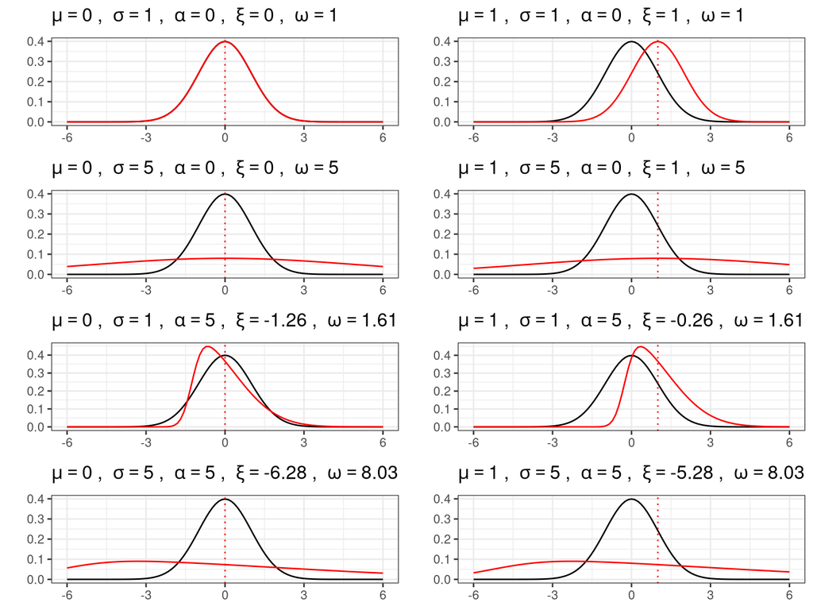

**Valori veri di $\eta$ e Cohen’s $d$**

Per il calcolo del vero overlapping ed il vero Cohen’s $d$ usiamo le seguenti funzioni:

```r
min_dskew_normal <- function( x = seq( -5, 5, by = .01 ), xi = 0, omega = 1, alpha = 0,
                              return.all = FALSE ) {

  require( sn )
  y1 <- dsn( x, xi = 0, omega = 1, alpha = 0 )
  y2 <- dsn( x, alpha = alpha, xi = xi, omega = omega )
  dy <- ifelse( y1 < y2, y1, y2 )
  gData <- data.frame( x, y1, y2, dy )

  if (return.all) {
    return( list( gData = gData ) )
  } else {
    return( dy )
  }
}

true_cohen <- function( mu1, mu2, sigma1, sigma2 ) {
  pool.s <- sqrt( (sigma1^2 + sigma2^2) / 2 )
  mu1-mu2 / pool.s
}
```

La funzione `min_dkew_normal()` ci permette di calcolare l’integrale esatto di sovrapposizione tra una normale ed una SN; la funzione `true_cohen()` calcola il vero Cohen’s $d$ a partire da medie e deviazioni standard delle popolazioni.

Ad esempio:

- Con $\mu = 0$, $\sigma = 1$ e $\alpha = 0$; le due distribuzioni sono uguali:

```r
# mu = 0, sigma = 1, alpha = 0
integrate( min_dskew_normal, -6, 6 )
```

```
1 with absolute error < 1.2e-07
```

```r
true_cohen( 0, 0, 1, 1 )
```

```
[1] 0
```

- Con $\mu = 1$, $\sigma = 1$ e $\alpha = 0$; le due distribuzioni hanno una differenza media di 1, ma essendo simmetriche, i parametri della SN sono uguali, $\xi = 1$ e $\omega = 1$:

```r
# mu = 1, sigma = 1, alpha = 0
integrate( min_dskew_normal, -6, 6, xi = 1, omega = 1 )
```

```
0.6170751 with absolute error < 4.2e-05
```

```r
true_cohen( 0, 1, 1, 1 )
```

```
[1] -1
```

- Con $\mu = 1$, $\sigma = 1$ e $\alpha = 5$; le due distribuzioni hanno una sempre una differenza media di 1, ma la seconda è asimmetrica, quindi i parametri della SN sono diversi, $\xi = -0.26$ e $\omega = 1.61$:

```r
# mu = 1, sigma = 1, alpha = 5
pars <- sninvpar( 1, 1, alpha = 5 )
integrate( min_dskew_normal, -6, 6,
           xi = pars$xi, omega = pars$omega, alpha = pars$alpha )
```

```
0.6451701 with absolute error < 3.5e-05
```

```r
true_cohen( 0, 1, 1, 1 )
```

```
[1] -1
```

Quindi comunque in questo caso il Cohen’s $d$ vero rimane -1; la questione della simulazione è: sarà altrettanto capace di catturare il valore vero anche quando c’è forte asimmetria?

**Algoritmo simulazione**

```r
core_sim <- function( DESIGN, B = 10 ) {

  require(overlapping)
  require(sn)
  require(effectsize)
  # set simulation parameters
  n <- DESIGN$n
  delta <- DESIGN$xi
  alpha <- DESIGN$alpha
  omega <- DESIGN$omega

  # calcolo mu e sigma
  MUSI <- snpar(xi = delta, omega = omega, alpha = alpha)

  cat( paste0( "n = ",n,"; mu = ",round(MUSI$mu,1),
               "; sigma = ",round(MUSI$sigma,2),"; alpha = ",
               round(alpha,2) ),"\n")

  # true population overlap
  true_overlap <- integrate( min_dskew_normal, -Inf, Inf, xi = delta, alpha = alpha,
                             omega = omega )$value

  # true population Cohen's d
  true_d <- true_cohen( mu1 = 0, mu2 = MUSI$mu, sigma1 = 1,
                        sigma2 = MUSI$sigma )

  # data simulation
  t( sapply(1:B, function(b){

    y1 <- rsn(n,xi=0, omega=1, alpha=0)
    y2 <- rsn(n,xi=delta, omega=omega,alpha=alpha)

    mx1 <- mean(y1); sx1 <- sd(y1)
    mx2 <- mean(y2); sx2 <- sd(y2)

    ETA1 <- overlap(list(y1,y2))$OV
    COHEN <- cohens_d(y1,y2)

    output <- c( mx1, sx1, mx2, sx2, ETA1, n,
                 delta, alpha, omega,
                 true_overlap, true_d, COHEN$Cohens_d)
    names(output) <- c( "mx1", "sx1", "mx2", "sx2", "eta", "n",
                 "xi","alpha","omega",
                "true_overlap", "true_d","Cohens_d")
    return(output)
  }) )
}
```

### Results

| mu | sigma | alpha | Freq |
| --- | --- | --- | --- |
| 0 | 1 | 0 | 15 |
| 1 | 1 | 0 | 15 |
| 0 | 5 | 0 | 15 |
| 1 | 5 | 0 | 15 |
| 0 | 1 | 5 | 15 |
| 1 | 1 | 5 | 15 |
| 0 | 5 | 5 | 15 |
| 1 | 5 | 5 | 15 |